# A4: Racial Disparities in Incarcerations

Thu La

2022-11-20

## Abstract

Incarceration trends has been an ongoing issue that’s been demonstrated to target minorities throughout the U.S. The Vera Institute compiled a dataset containing incarceration trends across U.S. counties since 1970 to 2018, and used this data to show that people of color have higher chances of incarcerations due to their race. This report will discuss the racial inequalities and show that minorities have a higher chance of going to prison.

## Introduction

According to the *Vera Institute*, the U.S prison population rose about 400 percent from 1970 to 2020. Over 80 percent of these arrests are a result of over-criminalization for low-level crimes related to poverty and people of color.

Issues that derived from over-criminalization includes overpopulated jails and prisons, disproportionate imprisonment of minorities, and long-lasting psychological and physical trauma. Using this data, we can see that the direct stakeholders affected by this would be jails and prison institutions because they are receiving incarcerated people and must provide for them. Another direct stakeholder could be policymakers that wants to use this data in order to understand the affected population and formulate ways to reduce the ongoing issues related to incarceration trends. Indirect stakeholders would be the citizens, depending the rules and regulations policymakers create, this can either exacerbate or reduce the issues on criminalization rates for minorities.

This data values statistical representation regarding incarceration trends based on gender and race in different factors. But since each person is represented by a number, a value tension that can arise from this could be oversimplification of data. This means that there are is no data for the reason of incarceration in order to have a deeper understanding of what issue is being used against which race the most and ways to improve these rules in the future.

##### The questions I will be researching using this data would be:

- Which county has the highest number of incarcerations in jail and prison in each state from 1970 to 2018?
- What are the incarceration changes over time in each state?

## Data Summary

The counties with the most jail population from 1970 to 2018 are

```
## # A tibble: 3,139 x 9
## # Groups:   total_jail_pop [2,823]
##    state location    total_jail_pop aapi_jail_pop black_jail_pop latinx_jail_pop
##    <chr> <chr>                <dbl>         <dbl>          <dbl>           <dbl>
##  1 CA    Los Angele~        809027.         8122.        225962.         304327.
##  2 NY    New York C~        619768          7457.        260350.         165713.
##  3 IL    Cook Count~        363060.         1314.        222858.          39576.
##  4 TX    Harris Cou~        326682.         5434.        146220.          24317.
##  5 PA    Philadelph~        260846.         1215.        158031.          28045.
##  6 AZ    Maricopa C~        244529          1135.         36461.          68609.
##  7 TX    Dallas Cou~        234858.          934.        104876.          32007.
##  8 FL    Miami-Dade~        216848.          396.         83025.          56697.
##  9 CA    Orange Cou~        207117          5447.         12715.          91958.
## 10 CA    San Diego ~        205754.         4854.         36179.          60725.
## # ... with 3,129 more rows, and 3 more variables: native_jail_pop <dbl>,
## #   white_jail_pop <dbl>, other_race_jail_pop <dbl>
```

We can see that Los Angeles County is the county with the highest jail population. In that county, the top three race populations are Latinx, Black, and White. The Latinx population has a count of about 304,327 people and that is about 37.6 percent of the total jail population for that county.

The county with the most prison population from 1970 to 2018 are

```
## # A tibble: 3,139 x 9
## # Groups:   total_prison_pop [2,453]
##    state location              total_prison_pop aapi_prison_pop black_prison_pop
##    <chr> <chr>                            <dbl>           <dbl>            <dbl>
##  1 CA    Los Angeles County, ~          1541460            6752           592955
##  2 NY    New York County, NY            1034770            5573           516809
##  3 TX    Harris County, TX               796242            1054           299449
##  4 IL    Cook County, IL                 689116               0           489897
##  5 TX    Dallas County, TX               534942             533           213250
##  6 MI    Wayne County, MI                444684             175           353186
##  7 PA    Philadelphia County,~           425614            2003           330280
##  8 AZ    Maricopa County, AZ             400305            1111            64362
##  9 CA    San Diego County, CA            328986            2688            92316
## 10 OH    Cuyahoga County, OH             292098              91            50861
## # ... with 3,129 more rows, and 4 more variables: latinx_prison_pop <dbl>,
## #   native_prison_pop <dbl>, white_prison_pop <dbl>,
## #   other_race_prison_pop <dbl>
```

Los Angeles County is also the county with the highest prison population with 1,541,460 people. The top three race populations for Los Angeles County are Black, Latinx, and White, with the Black population having 592,955 people and making up about 38.5 percent of the total jail population. This information corroborates with the issue that people of color are the most common population experiencing incarcerations.

This table shows jail population over time in each state

```
## # A tibble: 2,499 x 10
## # Groups:   state [51]
##     year state total_jail_pop aapi_jail_pop black_jail_pop latinx_jail_pop
##    <int> <chr>          <dbl>         <dbl>          <dbl>           <dbl>
##  1  1970 AK               100             0              0               0
##  2  1971 AK                 0             0              0               0
##  3  1972 AK                 0             0              0               0
##  4  1973 AK                 0             0              0               0
##  5  1974 AK                 0             0              0               0
##  6  1975 AK                 0             0              0               0
##  7  1976 AK                 0             0              0               0
##  8  1977 AK                 0             0              0               0
##  9  1978 AK                 7             0              0               0
## 10  1979 AK                 0             0              0               0
## # ... with 2,489 more rows, and 4 more variables: native_jail_pop <dbl>,
## #   white_jail_pop <dbl>, other_race_jail_pop <dbl>, pop_diff <dbl>
```

For prison, it is

```
## # A tibble: 2,499 x 10
## # Groups:   state [51]
##     year state total_prison_pop aapi_prison_pop black_prison_pop
##    <int> <chr>            <dbl>           <dbl>            <dbl>
##  1  1970 AK                   0               0                0
##  2  1971 AK                   0               0                0
##  3  1972 AK                   0               0                0
##  4  1973 AK                   0               0                0
##  5  1974 AK                   0               0                0
##  6  1975 AK                   0               0                0
##  7  1976 AK                   0               0                0
##  8  1977 AK                   0               0                0
##  9  1978 AK                   0               0                0
## 10  1979 AK                   0               0                0
## # ... with 2,489 more rows, and 5 more variables: latinx_prison_pop <dbl>,
## #   native_prison_pop <dbl>, white_prison_pop <dbl>,
## #   other_race_prison_pop <dbl>, pop_diff <dbl>
```

This data shows the yearly increase/decrease in jail populations and prison populations from 1970 to 2018.

##### This is a bar chart that shows the yearly jail population from 1970 to 2018:

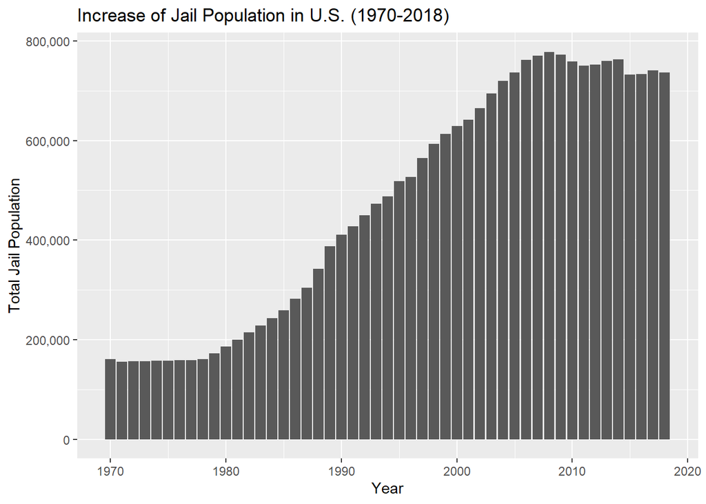

##### This line chart shows the growing jail population from 1970 to 2018 for each state:

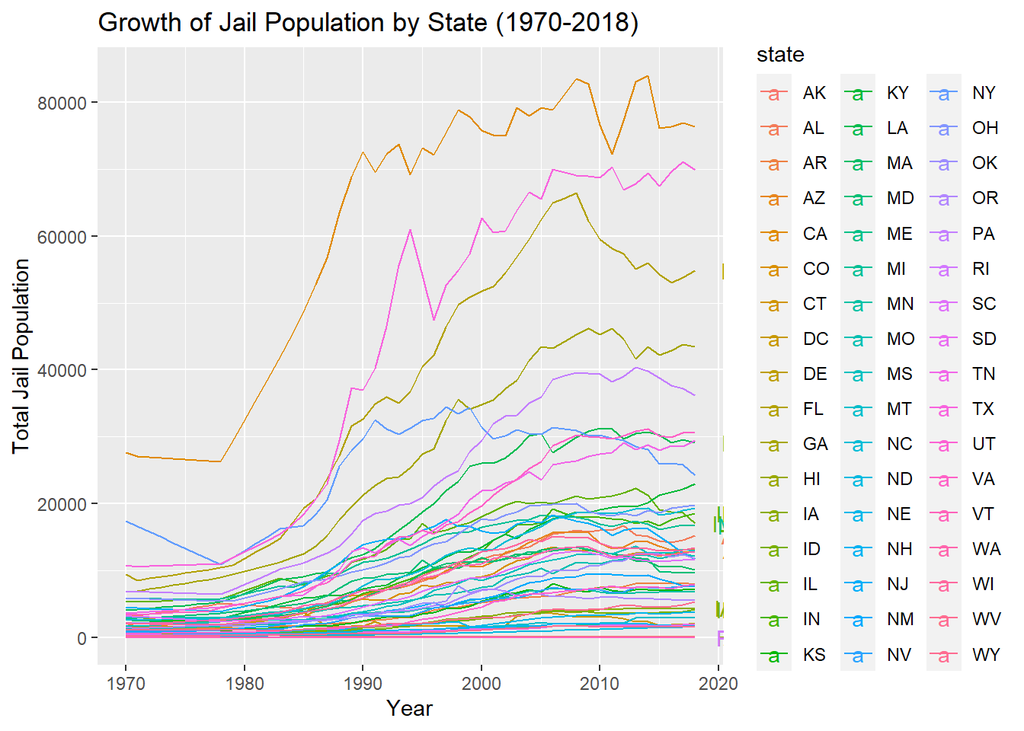

This chart shows that the state with the max jail population is California with about 75,000 people in 2018, followed by 70,000 in Texas, 55,000 in Florida, and 43,000 in Georgia.

##### This bar graph shows the race groups in jail population pertaining to each state:

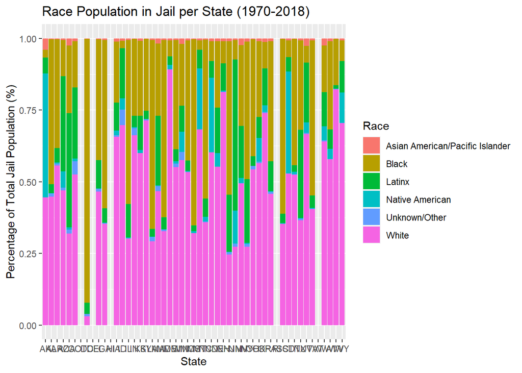

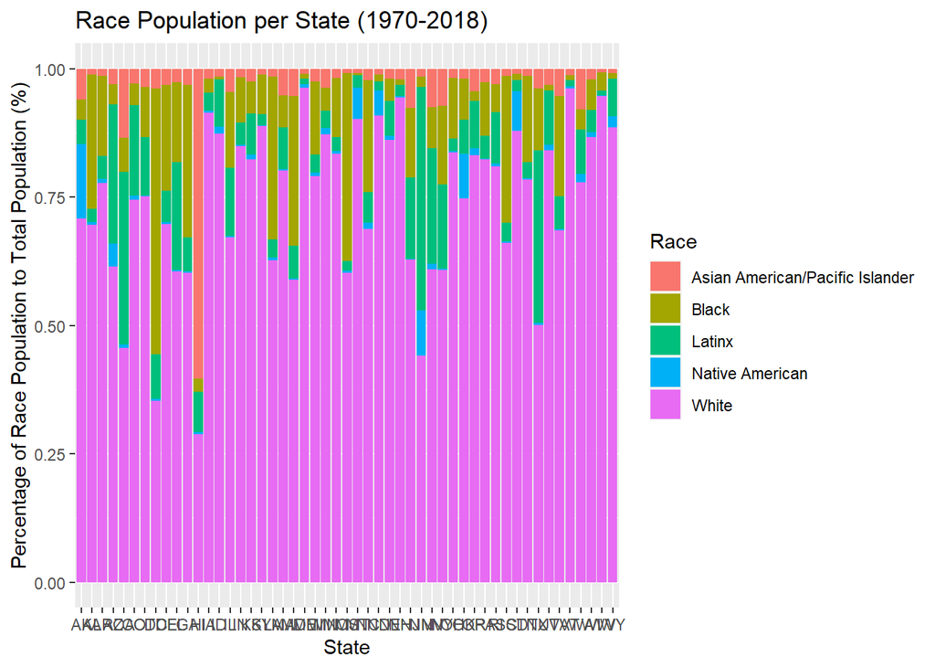